# John’s Weight Gain Delimma

### Step 2: Clean the data. Prepare the data and make a recipe for applying the steps needed to preprocess the data.

```r
skim(NHANES)
```

Data summary

| Name | NHANES |
| --- | --- |
| Number of rows | 10000 |
| Number of columns | 76 |
| _______________________ |  |
| Column type frequency: |  |
| factor | 31 |
| numeric | 45 |
| ________________________ |  |
| Group variables | None |

**Variable type: factor**

| skim_variable | n_missing | complete_rate | ordered | n_unique | top_counts |
| --- | --- | --- | --- | --- | --- |
| SurveyYr | 0 | 1.00 | FALSE | 2 | 200: 5000, 201: 5000 |
| Gender | 0 | 1.00 | FALSE | 2 | fem: 5020, mal: 4980 |
| AgeDecade | 333 | 0.97 | FALSE | 8 | 40: 1398, 0-: 1391, 10: 1374, 20: 1356 |
| Race1 | 0 | 1.00 | FALSE | 5 | Whi: 6372, Bla: 1197, Mex: 1015, Oth: 806 |
| Race3 | 5000 | 0.50 | FALSE | 6 | Whi: 3135, Bla: 589, Mex: 480, His: 350 |
| Education | 2779 | 0.72 | FALSE | 5 | Som: 2267, Col: 2098, Hig: 1517, 9 -: 888 |
| MaritalStatus | 2769 | 0.72 | FALSE | 6 | Mar: 3945, Nev: 1380, Div: 707, Liv: 560 |
| HHIncome | 811 | 0.92 | FALSE | 12 | mor: 2220, 750: 1084, 250: 958, 350: 863 |
| HomeOwn | 63 | 0.99 | FALSE | 3 | Own: 6425, Ren: 3287, Oth: 225 |
| Work | 2229 | 0.78 | FALSE | 3 | Wor: 4613, Not: 2847, Loo: 311 |
| BMICatUnder20yrs | 8726 | 0.13 | FALSE | 4 | Nor: 805, Obe: 221, Ove: 193, Und: 55 |
| BMI_WHO | 397 | 0.96 | FALSE | 4 | 18.: 2911, 30.: 2751, 25.: 2664, 12.: 1277 |
| Diabetes | 142 | 0.99 | FALSE | 2 | No: 9098, Yes: 760 |
| HealthGen | 2461 | 0.75 | FALSE | 5 | Goo: 2956, Vgo: 2508, Fai: 1010, Exc: 878 |
| LittleInterest | 3333 | 0.67 | FALSE | 3 | Non: 5103, Sev: 1130, Mos: 434 |
| Depressed | 3327 | 0.67 | FALSE | 3 | Non: 5246, Sev: 1009, Mos: 418 |
| SleepTrouble | 2228 | 0.78 | FALSE | 2 | No: 5799, Yes: 1973 |
| PhysActive | 1674 | 0.83 | FALSE | 2 | Yes: 4649, No: 3677 |
| TVHrsDay | 5141 | 0.49 | FALSE | 7 | 2_h: 1275, 1_h: 884, 3_h: 836, 0_t: 638 |
| CompHrsDay | 5137 | 0.49 | FALSE | 7 | 0_t: 1409, 0_h: 1073, 1_h: 1030, 2_h: 589 |
| Alcohol12PlusYr | 3420 | 0.66 | FALSE | 2 | Yes: 5212, No: 1368 |
| SmokeNow | 6789 | 0.32 | FALSE | 2 | No: 1745, Yes: 1466 |
| Smoke100 | 2765 | 0.72 | FALSE | 2 | No: 4024, Yes: 3211 |
| Smoke100n | 2765 | 0.72 | FALSE | 2 | Non: 4024, Smo: 3211 |
| Marijuana | 5059 | 0.49 | FALSE | 2 | Yes: 2892, No: 2049 |
| RegularMarij | 5059 | 0.49 | FALSE | 2 | No: 3575, Yes: 1366 |
| HardDrugs | 4235 | 0.58 | FALSE | 2 | No: 4700, Yes: 1065 |
| SexEver | 4233 | 0.58 | FALSE | 2 | Yes: 5544, No: 223 |
| SameSex | 4232 | 0.58 | FALSE | 2 | No: 5353, Yes: 415 |
| SexOrientation | 5158 | 0.48 | FALSE | 3 | Het: 4638, Bis: 119, Hom: 85 |
| PregnantNow | 8304 | 0.17 | FALSE | 3 | No: 1573, Yes: 72, Unk: 51 |

**Variable type: numeric**

| skim_variable | n_missing | complete_rate | mean | sd | p0 | p25 | p50 | p75 | p100 | hist |
| --- | --- | --- | --- | --- | --- | --- | --- | --- | --- | --- |
| ID | 0 | 1.00 | 61944.64 | 5871.17 | 51624.00 | 56904.50 | 62159.50 | 67039.00 | 71915.00 | ▇▇▇▇▇ |
| Age | 0 | 1.00 | 36.74 | 22.40 | 0.00 | 17.00 | 36.00 | 54.00 | 80.00 | ▇▇▇▆▅ |
| AgeMonths | 5038 | 0.50 | 420.12 | 259.04 | 0.00 | 199.00 | 418.00 | 624.00 | 959.00 | ▇▇▇▆▃ |
| HHIncomeMid | 811 | 0.92 | 57206.17 | 33020.28 | 2500.00 | 30000.00 | 50000.00 | 87500.00 | 100000.00 | ▃▆▃▁▇ |
| Poverty | 726 | 0.93 | 2.80 | 1.68 | 0.00 | 1.24 | 2.70 | 4.71 | 5.00 | ▅▅▃▃▇ |
| HomeRooms | 69 | 0.99 | 6.25 | 2.28 | 1.00 | 5.00 | 6.00 | 8.00 | 13.00 | ▂▆▇▂▁ |
| Weight | 78 | 0.99 | 70.98 | 29.13 | 2.80 | 56.10 | 72.70 | 88.90 | 230.70 | ▂▇▂▁▁ |
| Length | 9457 | 0.05 | 85.02 | 13.71 | 47.10 | 75.70 | 87.00 | 96.10 | 112.20 | ▁▃▆▇▃ |
| HeadCirc | 9912 | 0.01 | 41.18 | 2.31 | 34.20 | 39.58 | 41.45 | 42.92 | 45.40 | ▁▂▇▇▅ |
| Height | 353 | 0.96 | 161.88 | 20.19 | 83.60 | 156.80 | 166.00 | 174.50 | 200.40 | ▁▁▁▇▂ |
| BMI | 366 | 0.96 | 26.66 | 7.38 | 12.88 | 21.58 | 25.98 | 30.89 | 81.25 | ▇▆▁▁▁ |
| Pulse | 1437 | 0.86 | 73.56 | 12.16 | 40.00 | 64.00 | 72.00 | 82.00 | 136.00 | ▂▇▃▁▁ |
| BPSysAve | 1449 | 0.86 | 118.15 | 17.25 | 76.00 | 106.00 | 116.00 | 127.00 | 226.00 | ▃▇▂▁▁ |
| BPDiaAve | 1449 | 0.86 | 67.48 | 14.35 | 0.00 | 61.00 | 69.00 | 76.00 | 116.00 | ▁▁▇▇▁ |
| BPSys1 | 1763 | 0.82 | 119.09 | 17.50 | 72.00 | 106.00 | 116.00 | 128.00 | 232.00 | ▂▇▂▁▁ |
| BPDia1 | 1763 | 0.82 | 68.28 | 13.78 | 0.00 | 62.00 | 70.00 | 76.00 | 118.00 | ▁▁▇▆▁ |
| BPSys2 | 1647 | 0.84 | 118.48 | 17.49 | 76.00 | 106.00 | 116.00 | 128.00 | 226.00 | ▃▇▂▁▁ |
| BPDia2 | 1647 | 0.84 | 67.66 | 14.42 | 0.00 | 60.00 | 68.00 | 76.00 | 118.00 | ▁▁▇▆▁ |
| BPSys3 | 1635 | 0.84 | 117.93 | 17.18 | 76.00 | 106.00 | 116.00 | 126.00 | 226.00 | ▃▇▂▁▁ |
| BPDia3 | 1635 | 0.84 | 67.30 | 14.96 | 0.00 | 60.00 | 68.00 | 76.00 | 116.00 | ▁▁▇▇▁ |
| Testosterone | 5874 | 0.41 | 197.90 | 226.50 | 0.25 | 17.70 | 43.82 | 362.41 | 1795.60 | ▇▂▁▁▁ |
| DirectChol | 1526 | 0.85 | 1.36 | 0.40 | 0.39 | 1.09 | 1.29 | 1.58 | 4.03 | ▅▇▂▁▁ |
| TotChol | 1526 | 0.85 | 4.88 | 1.08 | 1.53 | 4.11 | 4.78 | 5.53 | 13.65 | ▂▇▁▁▁ |
| UrineVol1 | 987 | 0.90 | 118.52 | 90.34 | 0.00 | 50.00 | 94.00 | 164.00 | 510.00 | ▇▅▂▁▁ |
| UrineFlow1 | 1603 | 0.84 | 0.98 | 0.95 | 0.00 | 0.40 | 0.70 | 1.22 | 17.17 | ▇▁▁▁▁ |
| UrineVol2 | 8522 | 0.15 | 119.68 | 90.16 | 0.00 | 52.00 | 95.00 | 171.75 | 409.00 | ▇▆▃▂▁ |
| UrineFlow2 | 8524 | 0.15 | 1.15 | 1.07 | 0.00 | 0.48 | 0.76 | 1.51 | 13.69 | ▇▁▁▁▁ |
| DiabetesAge | 9371 | 0.06 | 48.42 | 15.68 | 1.00 | 40.00 | 50.00 | 58.00 | 80.00 | ▁▂▆▇▂ |
| DaysPhysHlthBad | 2468 | 0.75 | 3.33 | 7.40 | 0.00 | 0.00 | 0.00 | 3.00 | 30.00 | ▇▁▁▁▁ |
| DaysMentHlthBad | 2466 | 0.75 | 4.13 | 7.83 | 0.00 | 0.00 | 0.00 | 4.00 | 30.00 | ▇▁▁▁▁ |
| nPregnancies | 7396 | 0.26 | 3.03 | 1.80 | 1.00 | 2.00 | 3.00 | 4.00 | 32.00 | ▇▁▁▁▁ |
| nBabies | 7584 | 0.24 | 2.46 | 1.32 | 0.00 | 2.00 | 2.00 | 3.00 | 12.00 | ▇▅▁▁▁ |
| Age1stBaby | 8116 | 0.19 | 22.65 | 4.77 | 14.00 | 19.00 | 22.00 | 26.00 | 39.00 | ▆▇▅▂▁ |
| SleepHrsNight | 2245 | 0.78 | 6.93 | 1.35 | 2.00 | 6.00 | 7.00 | 8.00 | 12.00 | ▁▅▇▁▁ |
| PhysActiveDays | 5337 | 0.47 | 3.74 | 1.84 | 1.00 | 2.00 | 3.00 | 5.00 | 7.00 | ▇▇▃▅▅ |
| TVHrsDayChild | 9347 | 0.07 | 1.94 | 1.43 | 0.00 | 1.00 | 2.00 | 3.00 | 6.00 | ▇▆▂▂▂ |
| CompHrsDayChild | 9347 | 0.07 | 2.20 | 2.52 | 0.00 | 0.00 | 1.00 | 6.00 | 6.00 | ▇▁▁▁▃ |
| AlcoholDay | 5086 | 0.49 | 2.91 | 3.18 | 1.00 | 1.00 | 2.00 | 3.00 | 82.00 | ▇▁▁▁▁ |
| AlcoholYear | 4078 | 0.59 | 75.10 | 103.03 | 0.00 | 3.00 | 24.00 | 104.00 | 364.00 | ▇▁▁▁▁ |
| SmokeAge | 6920 | 0.31 | 17.83 | 5.33 | 6.00 | 15.00 | 17.00 | 19.00 | 72.00 | ▇▂▁▁▁ |
| AgeFirstMarij | 7109 | 0.29 | 17.02 | 3.90 | 1.00 | 15.00 | 16.00 | 19.00 | 48.00 | ▁▇▂▁▁ |
| AgeRegMarij | 8634 | 0.14 | 17.69 | 4.81 | 5.00 | 15.00 | 17.00 | 19.00 | 52.00 | ▂▇▁▁▁ |
| SexAge | 4460 | 0.55 | 17.43 | 3.72 | 9.00 | 15.00 | 17.00 | 19.00 | 50.00 | ▇▅▁▁▁ |
| SexNumPartnLife | 4275 | 0.57 | 15.09 | 57.85 | 0.00 | 2.00 | 5.00 | 12.00 | 2000.00 | ▇▁▁▁▁ |
| SexNumPartYear | 5072 | 0.49 | 1.34 | 2.78 | 0.00 | 1.00 | 1.00 | 1.00 | 69.00 | ▇▁▁▁▁ |

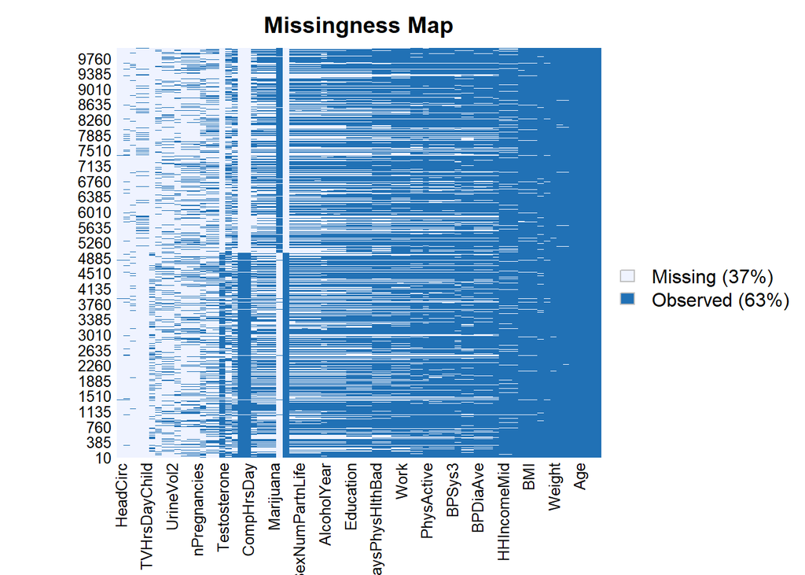

```r
Amelia::missmap(NHANES)
```

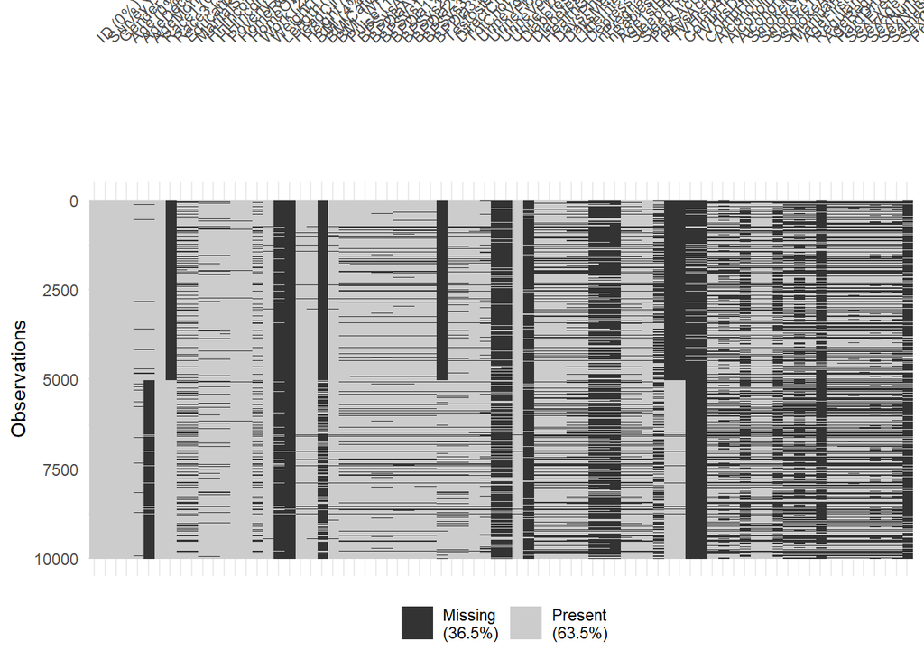

```r
naniar::vis_miss(NHANES)
```

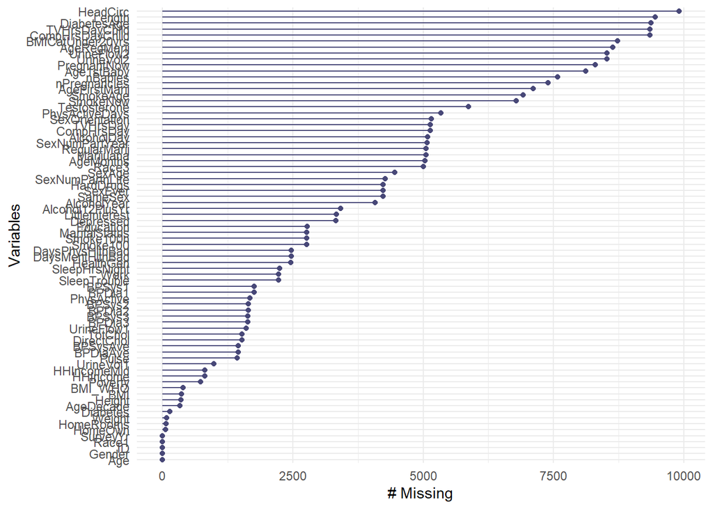

```r
naniar::gg_miss_var(NHANES)
```

```r
NHANES_weight <- NHANES |> select(-ID, -SleepTrouble) |>
  select( Weight, everything()) |>
  drop_na(Weight)
NHANES_weight
```

```
# A tibble: 9,922 × 74
   Weight SurveyYr Gender   Age AgeDecade AgeMonths Race1 Race3 Education
    <dbl> <fct>    <fct>  <int> <fct>         <int> <fct> <fct> <fct>
 1   87.4 2009_10  male      34 " 30-39"        409 White <NA>  High School
 2   87.4 2009_10  male      34 " 30-39"        409 White <NA>  High School
 3   87.4 2009_10  male      34 " 30-39"        409 White <NA>  High School
 4   17   2009_10  male       4 " 0-9"           49 Other <NA>  <NA>
 5   86.7 2009_10  female    49 " 40-49"        596 White <NA>  Some College
 6   29.8 2009_10  male       9 " 0-9"          115 White <NA>  <NA>
 7   35.2 2009_10  male       8 " 0-9"          101 White <NA>  <NA>
 8   75.7 2009_10  female    45 " 40-49"        541 White <NA>  College Grad
 9   75.7 2009_10  female    45 " 40-49"        541 White <NA>  College Grad
10   75.7 2009_10  female    45 " 40-49"        541 White <NA>  College Grad
# ℹ 9,912 more rows
# ℹ 65 more variables: MaritalStatus <fct>, HHIncome <fct>, HHIncomeMid <int>,
#   Poverty <dbl>, HomeRooms <int>, HomeOwn <fct>, Work <fct>, Length <dbl>,
#   HeadCirc <dbl>, Height <dbl>, BMI <dbl>, BMICatUnder20yrs <fct>,
#   BMI_WHO <fct>, Pulse <int>, BPSysAve <int>, BPDiaAve <int>, BPSys1 <int>,
#   BPDia1 <int>, BPSys2 <int>, BPDia2 <int>, BPSys3 <int>, BPDia3 <int>,
#   Testosterone <dbl>, DirectChol <dbl>, TotChol <dbl>, UrineVol1 <int>, …
```

Summarize the y-variable. This is the Null Model.

```r
NHANES_weight  |> group_by(Weight) |>
  summarize(n = n()) |>
  mutate(freq = n / sum(n))
```

```
# A tibble: 1,290 × 3
   Weight     n     freq
    <dbl> <int>    <dbl>
 1    2.8     1 0.000101
 2    3.6     1 0.000101
 3    4.2     1 0.000101
 4    4.5     2 0.000202
 5    4.6     1 0.000101
 6    4.7     2 0.000202
 7    4.8     4 0.000403
 8    5.1     2 0.000202
 9    5.3     2 0.000202
10    5.4     2 0.000202
# ℹ 1,280 more rows
```

We have summarized the Null-Model for our Predictions the next step is to make a split of the data.

Make the first split with 80% of the data being in the trainning data set.

```r
NHANES_weight_split <- initial_split(NHANES_weight, prop = 0.8)
NHANES_weight_split
```

```
<Training/Testing/Total>
<7937/1985/9922>
```

Training data.

```r
NHANES_weight_split |>
  training()
```

```
# A tibble: 7,937 × 74
   Weight SurveyYr Gender   Age AgeDecade AgeMonths Race1    Race3 Education
    <dbl> <fct>    <fct>  <int> <fct>         <int> <fct>    <fct> <fct>
 1   11.7 2009_10  female     2 " 0-9"           32 Other    <NA>  <NA>
 2   79.9 2011_12  female    20 " 20-29"         NA Black    Black Some College
 3   17.6 2009_10  male       6 " 0-9"           73 Other    <NA>  <NA>
 4   65.3 2009_10  female    37 " 30-39"        446 White    <NA>  College Grad
 5   71.3 2011_12  female    66 " 60-69"         NA White    White High School
 6  106.  2009_10  male      13 " 10-19"        159 Black    <NA>  <NA>
 7   49.1 2009_10  female    51 " 50-59"        616 Hispanic <NA>  Some College
 8   27.3 2009_10  female     5 " 0-9"           68 Black    <NA>  <NA>
 9  139.  2009_10  male      53 " 50-59"        639 White    <NA>  Some College
10   57.1 2009_10  female    41 " 40-49"        497 White    <NA>  High School
# ℹ 7,927 more rows
# ℹ 65 more variables: MaritalStatus <fct>, HHIncome <fct>, HHIncomeMid <int>,
#   Poverty <dbl>, HomeRooms <int>, HomeOwn <fct>, Work <fct>, Length <dbl>,
#   HeadCirc <dbl>, Height <dbl>, BMI <dbl>, BMICatUnder20yrs <fct>,
#   BMI_WHO <fct>, Pulse <int>, BPSysAve <int>, BPDiaAve <int>, BPSys1 <int>,
#   BPDia1 <int>, BPSys2 <int>, BPDia2 <int>, BPSys3 <int>, BPDia3 <int>,
#   Testosterone <dbl>, DirectChol <dbl>, TotChol <dbl>, UrineVol1 <int>, …
```

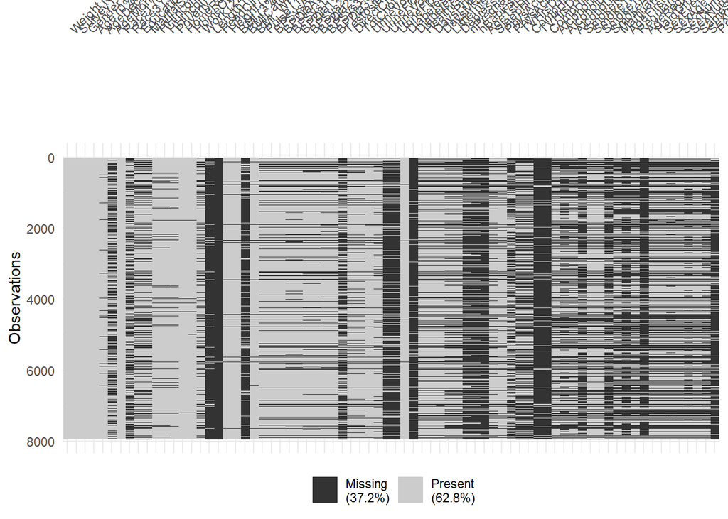

```r
NHANES_weight_split |>
  training() |>
  vis_miss()
```

```r
NHANES_weight_split |>
  testing()
```

```
# A tibble: 1,985 × 74
   Weight SurveyYr Gender   Age AgeDecade AgeMonths Race1 Race3 Education
    <dbl> <fct>    <fct>  <int> <fct>         <int> <fct> <fct> <fct>
 1   87.4 2009_10  male      34 " 30-39"        409 White <NA>  High School
 2   68   2009_10  male      66 " 60-69"        795 White <NA>  Some College
 3   38.6 2009_10  female    10 " 10-19"        123 White <NA>  <NA>
 4   57.5 2009_10  female    56 " 50-59"        677 White <NA>  College Grad
 5   40.1 2009_10  male       8 " 0-9"          104 White <NA>  <NA>
 6   62.8 2009_10  female    64 " 60-69"        771 Other <NA>  8th Grade
 7   54.3 2009_10  female    59 " 50-59"        718 Other <NA>  8th Grade
 8   57.7 2009_10  male      12 " 10-19"        152 Other <NA>  <NA>
 9   88.9 2009_10  male      16 " 10-19"        199 White <NA>  <NA>
10   78.2 2009_10  male      28 " 20-29"        336 Black <NA>  Some College
# ℹ 1,975 more rows
# ℹ 65 more variables: MaritalStatus <fct>, HHIncome <fct>, HHIncomeMid <int>,
#   Poverty <dbl>, HomeRooms <int>, HomeOwn <fct>, Work <fct>, Length <dbl>,
#   HeadCirc <dbl>, Height <dbl>, BMI <dbl>, BMICatUnder20yrs <fct>,
#   BMI_WHO <fct>, Pulse <int>, BPSysAve <int>, BPDiaAve <int>, BPSys1 <int>,
#   BPDia1 <int>, BPSys2 <int>, BPDia2 <int>, BPSys3 <int>, BPDia3 <int>,
#   Testosterone <dbl>, DirectChol <dbl>, TotChol <dbl>, UrineVol1 <int>, …
```

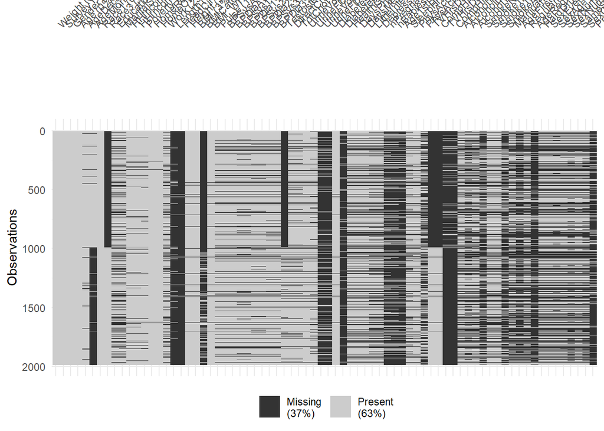

```r
NHANES_weight_split |>
  testing() |>
  vis_miss()
```

```r
NHANES_weight_recipe <- training(NHANES_weight_split) |>
  recipe(Weight ~ .) |>
  step_nzv(all_predictors()) |>
  step_impute_knn(all_predictors()) |>
  step_corr(all_numeric()) |>
  prep()

summary(NHANES_weight_recipe)
```

```
# A tibble: 65 × 4
   variable      type      role      source
   <chr>         <list>    <chr>     <chr>
 1 SurveyYr      <chr [3]> predictor original
 2 Gender        <chr [3]> predictor original
 3 Age           <chr [2]> predictor original
 4 AgeDecade     <chr [3]> predictor original
 5 Race1         <chr [3]> predictor original
 6 Race3         <chr [3]> predictor original
 7 Education     <chr [3]> predictor original
 8 MaritalStatus <chr [3]> predictor original
 9 HHIncome      <chr [3]> predictor original
10 HHIncomeMid   <chr [2]> predictor original
# ℹ 55 more rows
```

```r
tidy(NHANES_weight_recipe)
```

```
# A tibble: 3 × 6
  number operation type       trained skip  id
   <int> <chr>     <chr>      <lgl>   <lgl> <chr>
1      1 step      nzv        TRUE    FALSE nzv_fhTKK
2      2 step      impute_knn TRUE    FALSE impute_knn_1ESKm
3      3 step      corr       TRUE    FALSE corr_JxNlP
```

Note that the variable Weight is moved to the last column of the dataset.

The same thing above is going to happen but its just going to happen with Weight.

We “bake” the receipe into the Training data to see what the preprocesing does to the data. We do the same for the Testing data.

```r
NHANES_weight_training <- NHANES_weight_recipe |>
  bake(training(NHANES_weight_split))

NHANES_weight_training
```

```
# A tibble: 7,937 × 65
   SurveyYr Gender   Age AgeDecade Race1  Race3 Education MaritalStatus HHIncome
   <fct>    <fct>  <int> <fct>     <fct>  <fct> <fct>     <fct>         <fct>
 1 2009_10  female     2 " 0-9"    Other  Other College … NeverMarried  " 0-499…
 2 2011_12  female    20 " 20-29"  Black  Black Some Col… NeverMarried  "10000-…
 3 2009_10  male       6 " 0-9"    Other  Asian 8th Grade NeverMarried  "55000-…
 4 2009_10  female    37 " 30-39"  White  White College … Married       "more 9…
 5 2011_12  female    66 " 60-69"  White  White High Sch… Married       "more 9…
 6 2009_10  male      13 " 10-19"  Black  Black High Sch… NeverMarried  "15000-…
 7 2009_10  female    51 " 50-59"  Hispa… White Some Col… Married       "more 9…
 8 2009_10  female     5 " 0-9"    Black  Black High Sch… NeverMarried  "15000-…
 9 2009_10  male      53 " 50-59"  White  White Some Col… Married       "15000-…
10 2009_10  female    41 " 40-49"  White  White High Sch… Widowed       "more 9…
# ℹ 7,927 more rows
# ℹ 56 more variables: HHIncomeMid <int>, HomeRooms <int>, HomeOwn <fct>,
#   Work <fct>, Length <dbl>, HeadCirc <dbl>, Height <dbl>, BMI <dbl>,
#   BMICatUnder20yrs <fct>, BMI_WHO <fct>, Pulse <int>, BPDia1 <int>,
#   BPDia2 <int>, BPSys3 <int>, BPDia3 <int>, Testosterone <dbl>,
#   DirectChol <dbl>, TotChol <dbl>, UrineVol1 <int>, UrineFlow1 <dbl>,
#   UrineVol2 <int>, UrineFlow2 <dbl>, Diabetes <fct>, DiabetesAge <int>, …
```

```r
NHANES_weight_testing <- NHANES_weight_recipe |>
  bake(testing(NHANES_weight_split))

NHANES_weight_testing
```

```
# A tibble: 1,985 × 65
   SurveyYr Gender   Age AgeDecade Race1 Race3  Education MaritalStatus HHIncome
   <fct>    <fct>  <int> <fct>     <fct> <fct>  <fct>     <fct>         <fct>
 1 2009_10  male      34 " 30-39"  White White  High Sch… Married       25000-3…
 2 2009_10  male      66 " 60-69"  White White  Some Col… Married       25000-3…
 3 2009_10  female    10 " 10-19"  White White  9 - 11th… Separated     more 99…
 4 2009_10  female    56 " 50-59"  White White  College … Married       75000-9…
 5 2009_10  male       8 " 0-9"    White White  College … Married       65000-7…
 6 2009_10  female    64 " 60-69"  Other White  8th Grade Widowed       10000-1…
 7 2009_10  female    59 " 50-59"  Other Mexic… 8th Grade Widowed       20000-2…
 8 2009_10  male      12 " 10-19"  Other Asian  Some Col… NeverMarried  35000-4…
 9 2009_10  male      16 " 10-19"  White White  College … Married       more 99…
10 2009_10  male      28 " 20-29"  Black White  Some Col… LivePartner   25000-3…
# ℹ 1,975 more rows
# ℹ 56 more variables: HHIncomeMid <int>, HomeRooms <int>, HomeOwn <fct>,
#   Work <fct>, Length <dbl>, HeadCirc <dbl>, Height <dbl>, BMI <dbl>,
#   BMICatUnder20yrs <fct>, BMI_WHO <fct>, Pulse <int>, BPDia1 <int>,
#   BPDia2 <int>, BPSys3 <int>, BPDia3 <int>, Testosterone <dbl>,
#   DirectChol <dbl>, TotChol <dbl>, UrineVol1 <int>, UrineFlow1 <dbl>,
#   UrineVol2 <int>, UrineFlow2 <dbl>, Diabetes <fct>, DiabetesAge <int>, …
```

### Step 3: Training a model on the data

Setup the models.

```r
NHANES_weight_lm <- linear_reg() |>
  set_engine("lm") |>
  set_mode("regression") |>
  fit(Weight ~ ., data = NHANES_weight_training)
```

```r
predict(NHANES_weight_lm, NHANES_weight_testing)
```

```
# A tibble: 1,985 × 1
   .pred
   <dbl>
 1  90.3
 2  70.1
 3  33.3
 4  56.1
 5  47.9
 6  61.6
 7  51.7
 8  59.2
 9  88.0
10  78.5
# ℹ 1,975 more rows
```

```r
NHANES_weight_lm |>
  predict(NHANES_weight_testing) |>
  bind_cols(NHANES_weight_testing)
```

```
# A tibble: 1,985 × 66
   .pred SurveyYr Gender   Age AgeDecade Race1 Race3   Education   MaritalStatus
   <dbl> <fct>    <fct>  <int> <fct>     <fct> <fct>   <fct>       <fct>
 1  90.3 2009_10  male      34 " 30-39"  White White   High School Married
 2  70.1 2009_10  male      66 " 60-69"  White White   Some Colle… Married
 3  33.3 2009_10  female    10 " 10-19"  White White   9 - 11th G… Separated
 4  56.1 2009_10  female    56 " 50-59"  White White   College Gr… Married
 5  47.9 2009_10  male       8 " 0-9"    White White   College Gr… Married
 6  61.6 2009_10  female    64 " 60-69"  Other White   8th Grade   Widowed
 7  51.7 2009_10  female    59 " 50-59"  Other Mexican 8th Grade   Widowed
 8  59.2 2009_10  male      12 " 10-19"  Other Asian   Some Colle… NeverMarried
 9  88.0 2009_10  male      16 " 10-19"  White White   College Gr… Married
10  78.5 2009_10  male      28 " 20-29"  Black White   Some Colle… LivePartner
# ℹ 1,975 more rows
# ℹ 57 more variables: HHIncome <fct>, HHIncomeMid <int>, HomeRooms <int>,
#   HomeOwn <fct>, Work <fct>, Length <dbl>, HeadCirc <dbl>, Height <dbl>,
#   BMI <dbl>, BMICatUnder20yrs <fct>, BMI_WHO <fct>, Pulse <int>,
#   BPDia1 <int>, BPDia2 <int>, BPSys3 <int>, BPDia3 <int>, Testosterone <dbl>,
#   DirectChol <dbl>, TotChol <dbl>, UrineVol1 <int>, UrineFlow1 <dbl>,
#   UrineVol2 <int>, UrineFlow2 <dbl>, Diabetes <fct>, DiabetesAge <int>, …
```

### Step 4: Evaluate the models.

```r
NHANES_weight_lm |>
  predict(NHANES_weight_testing) |>
  bind_cols(NHANES_weight_testing) |>
  metrics(truth = Weight, estimate = .pred)
```

```
# A tibble: 3 × 3
  .metric .estimator .estimate
  <chr>   <chr>          <dbl>
1 rmse    standard       4.39
2 rsq     standard       0.977
3 mae     standard       2.75
```

```r
NHANES_weight_lm |>
  predict(NHANES_weight_testing) |>
  bind_cols(NHANES_weight_testing) |>
  rmse(truth = Weight, estimate = .pred)
```

```
# A tibble: 1 × 3
  .metric .estimator .estimate
  <chr>   <chr>          <dbl>
1 rmse    standard        4.39
```

### Step 5: Improve the model.

GLM model using regularization.

Setup the models.

```r
p_load(glmnet)
NHANES_weight_glm <- linear_reg(penalty = 0.001, mixture = 0.5) |>
  set_engine("glmnet") |>
  set_mode("regression") |>
  fit(Weight ~ ., data = NHANES_weight_training)
```

```r
predict(NHANES_weight_glm, NHANES_weight_testing)
```

```
# A tibble: 1,985 × 1
   .pred
   <dbl>
 1  90.8
 2  70.1
 3  33.8
 4  56.1
 5  47.7
 6  62.5
 7  52.9
 8  59.2
 9  87.8
10  78.8
# ℹ 1,975 more rows
```

```r
NHANES_weight_glm |>
  predict(NHANES_weight_testing) |>
  bind_cols(NHANES_weight_testing)
```

```
# A tibble: 1,985 × 66
   .pred SurveyYr Gender   Age AgeDecade Race1 Race3   Education   MaritalStatus
   <dbl> <fct>    <fct>  <int> <fct>     <fct> <fct>   <fct>       <fct>
 1  90.8 2009_10  male      34 " 30-39"  White White   High School Married
 2  70.1 2009_10  male      66 " 60-69"  White White   Some Colle… Married
 3  33.8 2009_10  female    10 " 10-19"  White White   9 - 11th G… Separated
 4  56.1 2009_10  female    56 " 50-59"  White White   College Gr… Married
 5  47.7 2009_10  male       8 " 0-9"    White White   College Gr… Married
 6  62.5 2009_10  female    64 " 60-69"  Other White   8th Grade   Widowed
 7  52.9 2009_10  female    59 " 50-59"  Other Mexican 8th Grade   Widowed
 8  59.2 2009_10  male      12 " 10-19"  Other Asian   Some Colle… NeverMarried
 9  87.8 2009_10  male      16 " 10-19"  White White   College Gr… Married
10  78.8 2009_10  male      28 " 20-29"  Black White   Some Colle… LivePartner
# ℹ 1,975 more rows
# ℹ 57 more variables: HHIncome <fct>, HHIncomeMid <int>, HomeRooms <int>,
#   HomeOwn <fct>, Work <fct>, Length <dbl>, HeadCirc <dbl>, Height <dbl>,
#   BMI <dbl>, BMICatUnder20yrs <fct>, BMI_WHO <fct>, Pulse <int>,
#   BPDia1 <int>, BPDia2 <int>, BPSys3 <int>, BPDia3 <int>, Testosterone <dbl>,
#   DirectChol <dbl>, TotChol <dbl>, UrineVol1 <int>, UrineFlow1 <dbl>,
#   UrineVol2 <int>, UrineFlow2 <dbl>, Diabetes <fct>, DiabetesAge <int>, …
```

```r
NHANES_weight_glm |>
  predict(NHANES_weight_testing) |>
  bind_cols(NHANES_weight_testing) |>
  metrics(truth = Weight, estimate = .pred)
```

```
# A tibble: 3 × 3
  .metric .estimator .estimate
  <chr>   <chr>          <dbl>
1 rmse    standard       4.39
2 rsq     standard       0.977
3 mae     standard       2.75
```

```r
NHANES_weight_glm |>
  predict(NHANES_weight_testing) |>
  bind_cols(NHANES_weight_testing) |>
  rmse(truth = Weight, estimate = .pred)
```

```
# A tibble: 1 × 3
  .metric .estimator .estimate
  <chr>   <chr>          <dbl>
1 rmse    standard        4.39
```

Setup the models.

```r
p_load(ranger)
NHANES_weight_ranger <- rand_forest(trees = 1000) |>
  set_engine("ranger") |>
  set_mode("regression") |>
  fit(Weight ~ ., data = NHANES_weight_testing)
```

```r
predict(NHANES_weight_ranger, NHANES_weight_testing)
```

```
# A tibble: 1,985 × 1
   .pred
   <dbl>
 1  89.9
 2  68.6
 3  40.6
 4  57.7
 5  39.1
 6  66.3
 7  59.6
 8  58.3
 9  87.3
10  78.3
# ℹ 1,975 more rows
```

```r
NHANES_weight_ranger |>
  predict(NHANES_weight_testing) |>
  bind_cols(NHANES_weight_testing)
```

```
# A tibble: 1,985 × 66
   .pred SurveyYr Gender   Age AgeDecade Race1 Race3   Education   MaritalStatus
   <dbl> <fct>    <fct>  <int> <fct>     <fct> <fct>   <fct>       <fct>
 1  89.9 2009_10  male      34 " 30-39"  White White   High School Married
 2  68.6 2009_10  male      66 " 60-69"  White White   Some Colle… Married
 3  40.6 2009_10  female    10 " 10-19"  White White   9 - 11th G… Separated
 4  57.7 2009_10  female    56 " 50-59"  White White   College Gr… Married
 5  39.1 2009_10  male       8 " 0-9"    White White   College Gr… Married
 6  66.3 2009_10  female    64 " 60-69"  Other White   8th Grade   Widowed
 7  59.6 2009_10  female    59 " 50-59"  Other Mexican 8th Grade   Widowed
 8  58.3 2009_10  male      12 " 10-19"  Other Asian   Some Colle… NeverMarried
 9  87.3 2009_10  male      16 " 10-19"  White White   College Gr… Married
10  78.3 2009_10  male      28 " 20-29"  Black White   Some Colle… LivePartner
# ℹ 1,975 more rows
# ℹ 57 more variables: HHIncome <fct>, HHIncomeMid <int>, HomeRooms <int>,
#   HomeOwn <fct>, Work <fct>, Length <dbl>, HeadCirc <dbl>, Height <dbl>,
#   BMI <dbl>, BMICatUnder20yrs <fct>, BMI_WHO <fct>, Pulse <int>,
#   BPDia1 <int>, BPDia2 <int>, BPSys3 <int>, BPDia3 <int>, Testosterone <dbl>,
#   DirectChol <dbl>, TotChol <dbl>, UrineVol1 <int>, UrineFlow1 <dbl>,
#   UrineVol2 <int>, UrineFlow2 <dbl>, Diabetes <fct>, DiabetesAge <int>, …
```

```r
NHANES_weight_ranger |>
  predict(NHANES_weight_testing) |>
  bind_cols(NHANES_weight_testing) |>
  metrics(truth = Weight, estimate = .pred)
```

```
# A tibble: 3 × 3
  .metric .estimator .estimate
  <chr>   <chr>          <dbl>
1 rmse    standard       3.32
2 rsq     standard       0.990
3 mae     standard       1.72
```

```r
NHANES_weight_ranger |>
  predict(NHANES_weight_testing) |>
  bind_cols(NHANES_weight_testing) |>
  rmse(truth = Weight, estimate = .pred)
```

```
# A tibble: 1 × 3
  .metric .estimator .estimate
  <chr>   <chr>          <dbl>
1 rmse    standard        3.32
```